# Week 10 Part 2

# 1 Chapter 15, Screening Many Models

What if we don’t know which model to use?

## 1.1 Workflow Sets

```r
data(concrete, package = "modeldata")
glimpse(concrete)
```

```
## Rows: 1,030
## Columns: 9
## $ cement               <dbl> 540.0, 540.0, 332.5, 332.5, 198.6, 266.0, 380.0, …
## $ blast_furnace_slag   <dbl> 0.0, 0.0, 142.5, 142.5, 132.4, 114.0, 95.0, 95.0,…
## $ fly_ash              <dbl> 0, 0, 0, 0, 0, 0, 0, 0, 0, 0, 0, 0, 0, 0, 0, 0, 0…
## $ water                <dbl> 162, 162, 228, 228, 192, 228, 228, 228, 228, 228,…
## $ superplasticizer     <dbl> 2.5, 2.5, 0.0, 0.0, 0.0, 0.0, 0.0, 0.0, 0.0, 0.0,…
## $ coarse_aggregate     <dbl> 1040.0, 1055.0, 932.0, 932.0, 978.4, 932.0, 932.0…
## $ fine_aggregate       <dbl> 676.0, 676.0, 594.0, 594.0, 825.5, 670.0, 594.0, …
## $ age                  <int> 28, 28, 270, 365, 360, 90, 365, 28, 28, 28, 90, 2…
## $ compressive_strength <dbl> 79.99, 61.89, 40.27, 41.05, 44.30, 47.03, 43.70, …
```

```r
concrete <-
   concrete %>%
   group_by(across(-compressive_strength)) %>%
   summarize(compressive_strength = mean(compressive_strength),
             .groups = "drop")
nrow(concrete)
```

```
## [1] 992
```

```r
set.seed(1501)
concrete_split <- initial_split(concrete, strata = compressive_strength)
concrete_train <- training(concrete_split)
concrete_test  <- testing(concrete_split)

set.seed(1502)
concrete_folds_mini <-
   vfold_cv(concrete_train, strata = compressive_strength, repeats=1, v=3)

normalized_rec <-
   recipe(compressive_strength ~ ., data = concrete_train) %>%
   step_normalize(all_predictors())

poly_recipe <-
   normalized_rec %>%
   step_poly(all_predictors()) %>%
   step_interact(~ all_predictors():all_predictors())
```

Some models (notably neural networks, K-nearest neighbors, and support vector machines) require predictors that have been centered and scaled, so some model workflows will require recipes with these preprocessing steps. For other models, a traditional response surface design model expansion (i.e., quadratic and two-way interactions) is a good idea. For these purposes, we create two recipes:

```r
library(rules)
library(baguette)

linear_reg_spec <-
   linear_reg(penalty = tune(), mixture = tune()) %>%
   set_engine("glmnet")

nnet_spec <-
   mlp(hidden_units = tune(), penalty = tune(), epochs = tune()) %>%
   set_engine("nnet", MaxNWts = 2600) %>%
   set_mode("regression")

mars_spec <-
   mars(prod_degree = tune()) %>%  #<- use GCV to choose terms
   set_engine("earth") %>%
   set_mode("regression")

svm_r_spec <-
   svm_rbf(cost = tune(), rbf_sigma = tune()) %>%
   set_engine("kernlab") %>%
   set_mode("regression")

svm_p_spec <-
   svm_poly(cost = tune(), degree = tune()) %>%
   set_engine("kernlab") %>%
   set_mode("regression")

knn_spec <-
   nearest_neighbor(neighbors = tune(), dist_power = tune(), weight_func = tune()) %>%
   set_engine("kknn") %>%
   set_mode("regression")

cart_spec <-
   decision_tree(cost_complexity = tune(), min_n = tune()) %>%
   set_engine("rpart") %>%
   set_mode("regression")

bag_cart_spec <-
   bag_tree() %>%
   set_engine("rpart", times = 50L) %>%
   set_mode("regression")

rf_spec <-
   rand_forest(mtry = tune(), min_n = tune(), trees = 1000) %>%
   set_engine("ranger") %>%
   set_mode("regression")

xgb_spec <-
   boost_tree(tree_depth = tune(), learn_rate = tune(), loss_reduction = tune(),
              min_n = tune(), sample_size = tune(), trees = tune()) %>%
   set_engine("xgboost") %>%
   set_mode("regression")

cubist_spec <-
   cubist_rules(committees = tune(), neighbors = tune()) %>%
   set_engine("Cubist")

nnet_param <-
   nnet_spec %>%
   extract_parameter_set_dials() %>%
   update(hidden_units = hidden_units(c(1, 27)))
```

As a first workflow set example, let’s combine the recipe that only standardizes the predictors to the nonlinear models that require that the predictors be in the same units.

```r
normalized <-
   workflow_set(
      preproc = list(normalized = normalized_rec),
      models = list(SVM_radial = svm_r_spec, SVM_poly = svm_p_spec,
                    KNN = knn_spec, neural_network = nnet_spec)
   )
normalized
```

| wflow_id | info | option | result |
| --- | --- | --- | --- |
| normalized_SVM_radial |  |  |  |
| normalized_SVM_poly |  |  |  |
| normalized_KNN |  |  |  |
| normalized_neural_network |  |  |  |

```r
normalized %>% extract_workflow(id = "normalized_KNN")
```

```
## ══ Workflow ════════════════════════════════════════════════════════════════════
## Preprocessor: Recipe
## Model: nearest_neighbor()
##
## ── Preprocessor ────────────────────────────────────────────────────────────────
## 1 Recipe Step
##
## • step_normalize()
##
## ── Model ───────────────────────────────────────────────────────────────────────
## K-Nearest Neighbor Model Specification (regression)
##
## Main Arguments:
##   neighbors = tune()
##   weight_func = tune()
##   dist_power = tune()
##
## Computational engine: kknn
```

```r
normalized <-
   normalized %>%
   option_add(param_info = nnet_param, id = "normalized_neural_network")
```

For the other nonlinear models, let’s create another workflow set that uses dplyr selectors for the outcome and predictors:

```r
model_vars <-
   workflow_variables(outcomes = compressive_strength,
                      predictors = everything())

no_pre_proc <-
   workflow_set(
      preproc = list(simple = model_vars),
      models = list(MARS = mars_spec, CART = cart_spec, CART_bagged = bag_cart_spec,
                    RF = rf_spec, boosting = xgb_spec, Cubist = cubist_spec)
   )
no_pre_proc
```

| wflow_id | info | option | result |
| --- | --- | --- | --- |
| simple_MARS |  |  |  |
| simple_CART |  |  |  |
| simple_CART_bagged |  |  |  |
| simple_RF |  |  |  |
| simple_boosting |  |  |  |
| simple_Cubist |  |  |  |

Finally, the set that uses nonlinear terms and interactions with the appropriate models are assembled:

```r
with_features <-
   workflow_set(
      preproc = list(full_quad = poly_recipe),
      models = list(linear_reg = linear_reg_spec, KNN = knn_spec)
   )
```

```r
all_workflows <-
   bind_rows(no_pre_proc, normalized, with_features) %>%
   # Make the workflow ID's a little more simple:
   mutate(wflow_id = gsub("(simple_)|(normalized_)", "", wflow_id))
all_workflows
```

| wflow_id | info | option | result |
| --- | --- | --- | --- |
| MARS |  |  |  |
| CART |  |  |  |
| CART_bagged |  |  |  |
| RF |  |  |  |
| boosting |  |  |  |
| Cubist |  |  |  |
| SVM_radial |  |  |  |
| SVM_poly |  |  |  |
| KNN |  |  |  |
| neural_network |  |  |  |

[output cut: 2 more lines]

## 1.2 Tuning

Almost all of these workflows contain tuning parameters. In order to evaluate their performance, we can use the standard tuning or resampling functions (e.g., `tune_grid()` and so on). The `workflow_map()` function will apply the same function to all of the workflows in the set; the default is `tune_grid()`.

```r
grid_ctrl <-
   control_grid(
      save_pred = TRUE,
      parallel_over = "everything",
      save_workflow = TRUE
   )

grid_results <-
   all_workflows %>%
   workflow_map(
      seed = 1503,
      resamples = concrete_folds_mini,
      grid = 5,
      control = grid_ctrl,
      verbose = TRUE
   )
```

```
## i  1 of 12 tuning:     MARS
```

```
## ✔  1 of 12 tuning:     MARS (1.1s)
```

```
## i  2 of 12 tuning:     CART
```

```
## ✔  2 of 12 tuning:     CART (2.5s)
```

```
## i    No tuning parameters. `fit_resamples()` will be attempted
```

```
## i  3 of 12 resampling: CART_bagged
```

```
## ✔  3 of 12 resampling: CART_bagged (8.5s)
```

```
## i  4 of 12 tuning:     RF
```

```
## i Creating pre-processing data to finalize unknown parameter: mtry
```

```
## ✔  4 of 12 tuning:     RF (4.7s)
```

```
## i  5 of 12 tuning:     boosting
```

```
## ✔  5 of 12 tuning:     boosting (8.4s)
```

```
## i  6 of 12 tuning:     Cubist
```

```
## ✔  6 of 12 tuning:     Cubist (6.3s)
```

```
## i  7 of 12 tuning:     SVM_radial
```

```
## ✔  7 of 12 tuning:     SVM_radial (4.1s)
```

```
## i  8 of 12 tuning:     SVM_poly
```

```
## ✔  8 of 12 tuning:     SVM_poly (6.5s)
```

```
## i  9 of 12 tuning:     KNN
```

```
## ✔  9 of 12 tuning:     KNN (5.1s)
```

```
## i 10 of 12 tuning:     neural_network
```

```
## ✔ 10 of 12 tuning:     neural_network (7.4s)
```

```
## i 11 of 12 tuning:     full_quad_linear_reg
```

```
## ✔ 11 of 12 tuning:     full_quad_linear_reg (6.1s)
```

```
## i 12 of 12 tuning:     full_quad_KNN
```

```
## ✔ 12 of 12 tuning:     full_quad_KNN (36.5s)
```

```r
num_grid_models <- nrow(collect_metrics(grid_results, summarize = FALSE))
```

```r
grid_results %>%
   rank_results() %>%
   filter(.metric == "rmse") %>%
   select(model, .config, rmse = mean, rank)
```

| model | .config | rmse | rank |
| --- | --- | --- | --- |
| boost_tree | Preprocessor1_Model5 | 4.846884 | 1 |
| cubist_rules | Preprocessor1_Model4 | 5.076604 | 2 |
| boost_tree | Preprocessor1_Model2 | 5.103036 | 3 |
| cubist_rules | Preprocessor1_Model1 | 5.169229 | 4 |
| cubist_rules | Preprocessor1_Model2 | 5.204373 | 5 |
| cubist_rules | Preprocessor1_Model3 | 5.224186 | 6 |
| cubist_rules | Preprocessor1_Model5 | 5.393844 | 7 |
| boost_tree | Preprocessor1_Model1 | 5.652192 | 8 |
| bag_tree | Preprocessor1_Model1 | 5.846350 | 9 |
| rand_forest | Preprocessor1_Model1 | 5.881863 | 10 |

[output cut: 43 more lines]

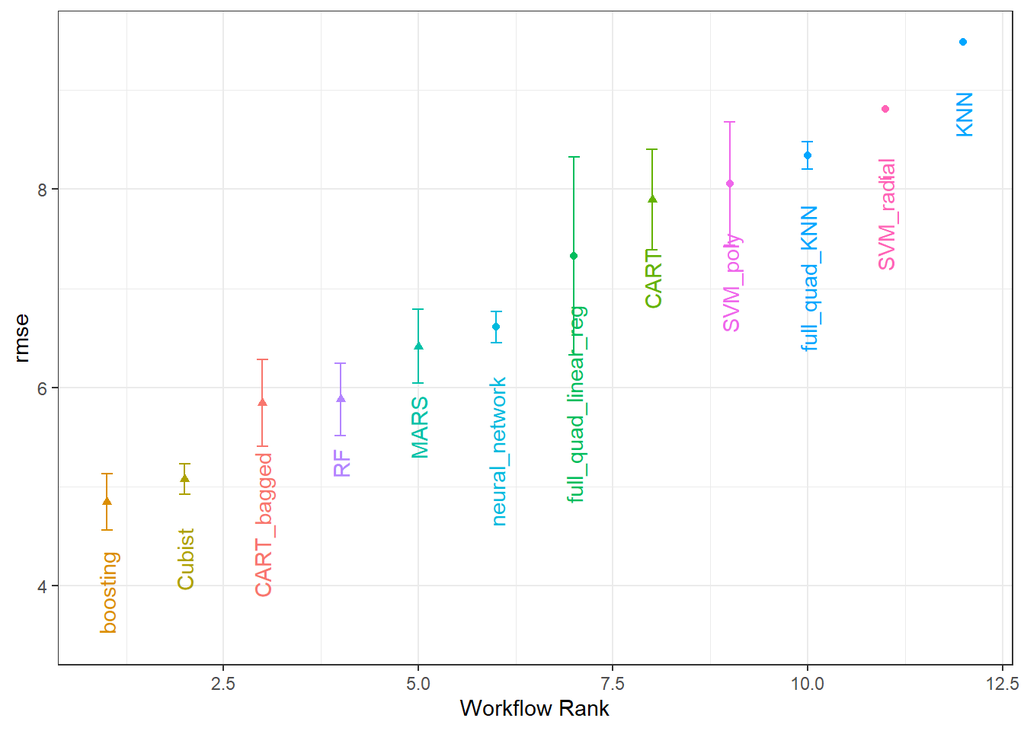

```r
autoplot(
   grid_results,
   rank_metric = "rmse",  # <- how to order models
   metric = "rmse",       # <- which metric to visualize
   select_best = TRUE     # <- one point per workflow
) +
   geom_text(aes(y = mean - 1/2, label = wflow_id), angle = 90, hjust = 1) +
   lims(y = c(3.5, 9.5)) +
   theme(legend.position = "none")
```

## 1.3 Efficiently Screening Models

```r
library(finetune)

concrete_folds <-
   vfold_cv(concrete_train, strata = compressive_strength, repeats=1, v=5)

race_ctrl <-
   control_race(
      save_pred = TRUE,
      parallel_over = "everything",
      save_workflow = TRUE
   )

race_results <-
   all_workflows %>%
   workflow_map(
      "tune_race_anova",
      seed = 1503,
      resamples = concrete_folds,
      grid = 5,
      control = race_ctrl,
      verbose = TRUE
   )
```

```
## i  1 of 12 tuning:     MARS
```

```
## ✔  1 of 12 tuning:     MARS (2.7s)
```

```
## i  2 of 12 tuning:     CART
```

```
## ✔  2 of 12 tuning:     CART (3.2s)
```

```
## i    No tuning parameters. `fit_resamples()` will be attempted
```

```
## i  3 of 12 resampling: CART_bagged
```

```
## ✔  3 of 12 resampling: CART_bagged (13.9s)
```

```
## i  4 of 12 tuning:     RF
```

```
## i Creating pre-processing data to finalize unknown parameter: mtry
```

```
## ✔  4 of 12 tuning:     RF (7.4s)
```

```
## i  5 of 12 tuning:     boosting
```

```
## ✔  5 of 12 tuning:     boosting (16.7s)
```

```
## i  6 of 12 tuning:     Cubist
```

```
## ✔  6 of 12 tuning:     Cubist (9s)
```

```
## i  7 of 12 tuning:     SVM_radial
```

```
## ✔  7 of 12 tuning:     SVM_radial (4.7s)
```

```
## i  8 of 12 tuning:     SVM_poly
```

```
## ✔  8 of 12 tuning:     SVM_poly (10.6s)
```

```
## i  9 of 12 tuning:     KNN
```

```
## ✔  9 of 12 tuning:     KNN (8.1s)
```

```
## i 10 of 12 tuning:     neural_network
```

```
## ✔ 10 of 12 tuning:     neural_network (13.5s)
```

```
## i 11 of 12 tuning:     full_quad_linear_reg
```

```
## ✔ 11 of 12 tuning:     full_quad_linear_reg (6.9s)
```

```
## i 12 of 12 tuning:     full_quad_KNN
```

```
## ✔ 12 of 12 tuning:     full_quad_KNN (47.7s)
```

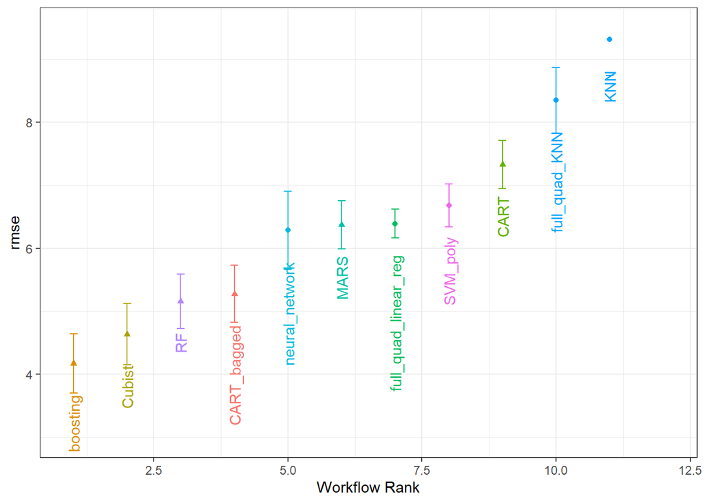

```r
autoplot(
   race_results,
   rank_metric = "rmse",
   metric = "rmse",
   select_best = TRUE
) +
   geom_text(aes(y = mean - 1/2, label = wflow_id), angle = 90, hjust = 1) +
   lims(y = c(3.0, 9.5)) +
   theme(legend.position = "none")
```

## 1.4 Finalize Model

```r
best_results <-
   race_results %>%
   extract_workflow_set_result("boosting") %>%
   select_best(metric = "rmse")
best_results
```

| trees | min_n | tree_depth | learn_rate | loss_reduction | sample_size | .config |
| --- | --- | --- | --- | --- | --- | --- |
| 1688 | 5 | 13 | 0.02710193 | 1.740535e-06 | 0.8720639 | Preprocessor1_Model1 |

```r
boosting_test_results <-
   race_results %>%
   extract_workflow("boosting") %>%
   finalize_workflow(best_results) %>%
   last_fit(split = concrete_split)
```

```r
collect_metrics(boosting_test_results)
```

| .metric | .estimator | .estimate | .config |
| --- | --- | --- | --- |
| rmse | standard | 3.3354268 | Preprocessor1_Model1 |
| rsq | standard | 0.9553514 | Preprocessor1_Model1 |

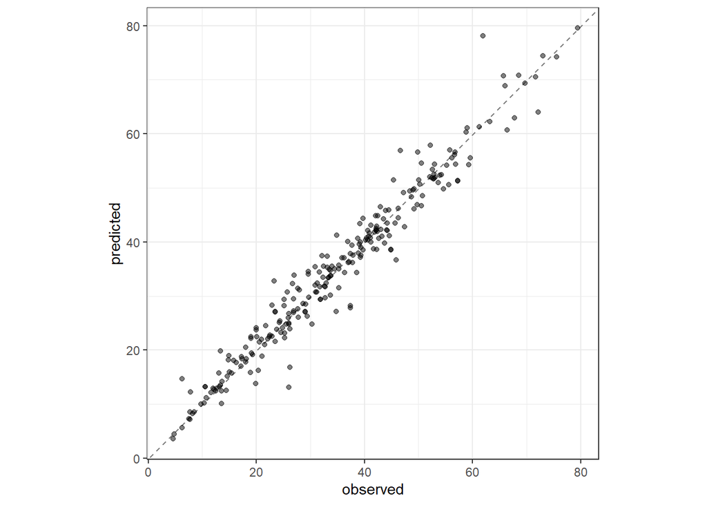

```r
boosting_test_results %>%
   collect_predictions() %>%
   ggplot(aes(x = compressive_strength, y = .pred)) +
   geom_abline(color = "gray50", lty = 2) +
   geom_point(alpha = 0.5) +
   coord_obs_pred() +
   labs(x = "observed", y = "predicted")
```